# Reproducible Research: Peer Assessment 1

## Loading and preprocessing the data

First we need to unzip the file *“activity.zip”*, then we can read it into a data frame *df*.

```r
unzip ("activity.zip")
df <- read.csv("activity.csv")
```

We are converting the dates to *date values*.

```r
df$date <- as.Date(df$date)
```

The intervals are integers. However, they are formatted such that the last two digits give the minutes of the interval, while the prior digits give the hour. We convert them such that they are converted to an integer representing the number of minutes until the start of that interval.

```r
df$interval <- floor(df$interval/100)*60+(df$interval%%100)
```

## What is mean total number of steps taken per day?

First we extract the distinct values for date.

```r
dates <- factor(df$date)
```

We can than add up the steps by day, using *tapply*, removing missing values.

```r
byDates <- tapply(df$steps, dates, sum, na.rm=TRUE)
```

And then we produce the histogram.

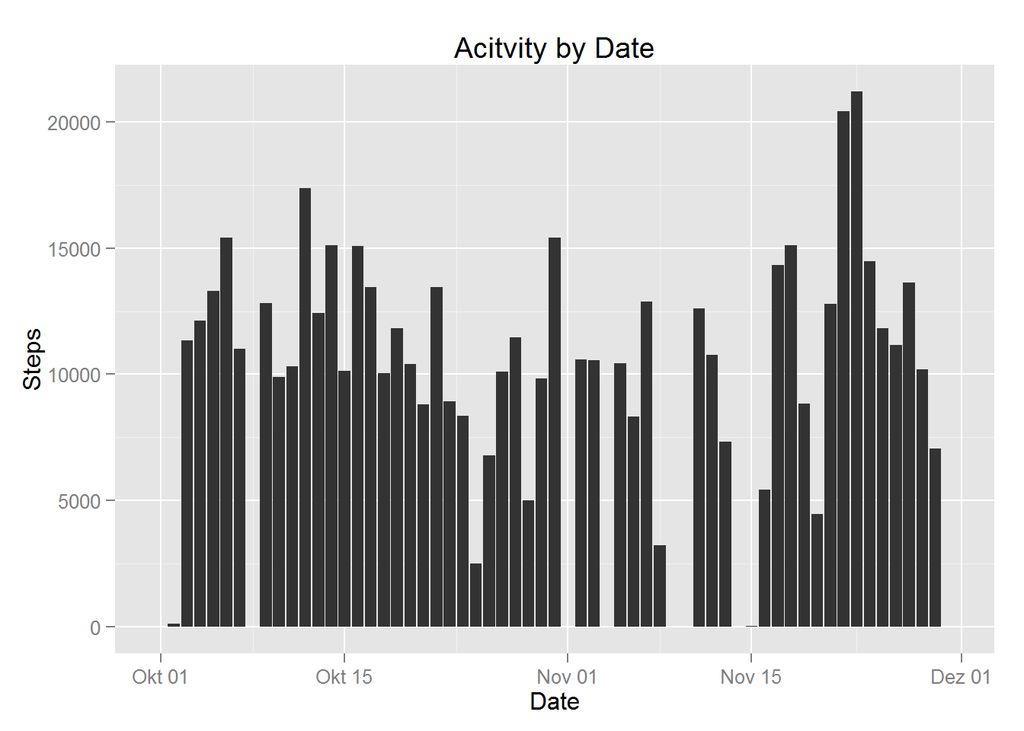

```r
library(ggplot2)
qplot(x=as.Date(names(byDates)), y=byDates, geom="histogram", stat="identity", xlab="Date", ylab="Steps",
      main="Acitvity by Date", axis = FALSE)
```

Now all is left in this part is to report the daily *mean* and *median* steps taken.

```r
mean(byDates)
```

```
## [1] 9354
```

```r
median(byDates)
```

```
## [1] 10395
```

## What is the average daily activity pattern?

This is similar to the previous exercise. We extract the factors, compute the averages and plot them.

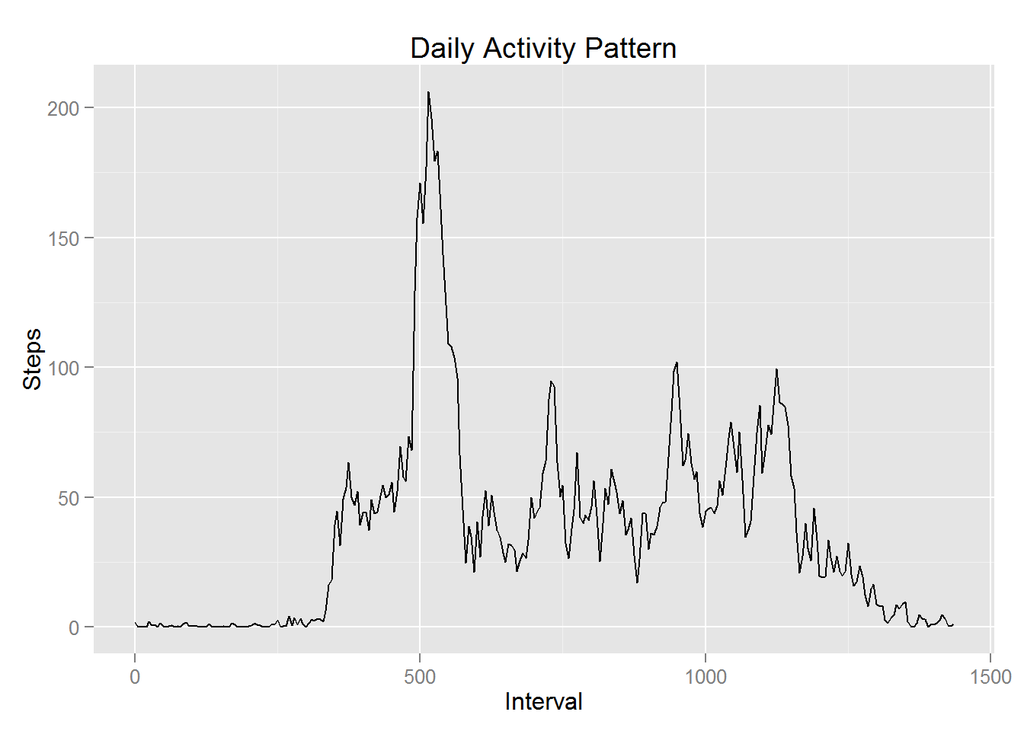

```r
intervals <- factor(df$interval)
byIntervals <- tapply(df$steps, intervals, mean, na.rm=TRUE)
qplot(x=as.integer(names(byIntervals)), y=byIntervals, geom="line",
      stat="identity", xlab="Interval",
      ylab="Steps", main="Daily Activity Pattern")
```

In order to get the interval with the maximum number of steps, we use *which.max*.

```r
which.max(byIntervals)
```

```
## 515
## 104
```

Interpretation of result: the 104th value, which contains interval **515** represents the maximum average number of steps taken.

## Imputing missing values

First we create a second data frame *df2* to be manipulated.

```r
df2 <- df
```

```r
missing <- is.na(df2$steps)
```

We then use the averages for the respective interval to fill the data. This seems to be a reasonable approach.

```r
df2$steps[missing] <- floor(byIntervals[df2$interval[missing]/5+1])
sum(is.na(df2$steps))
```

```
## [1] 0
```

```r
byDates2 <- tapply(df2$steps, dates, sum)
mean(byDates)
```

```
## [1] 9354
```

```r
median(byDates)
```

```
## [1] 10395
```

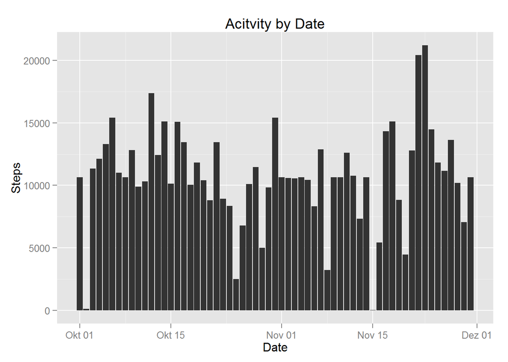

```r
qplot(x=as.Date(names(byDates2)), y=byDates2, geom="histogram", stat="identity", xlab="Date", ylab="Steps",
      main="Acitvity by Date", axis = FALSE)
```

## Are there differences in activity patterns between weekdays and weekends?

First we need to create a new variable *wd* which is *TRUE* if the date is a weekday, and *FALSE* if it is a weekend.

```r
wd <- (as.POSIXlt(df$date)$wday>0)&(as.POSIXlt(df$date)$wday<6)
df <- cbind(df, wd)
```

We can than recalculate the interval means using a list of factors.

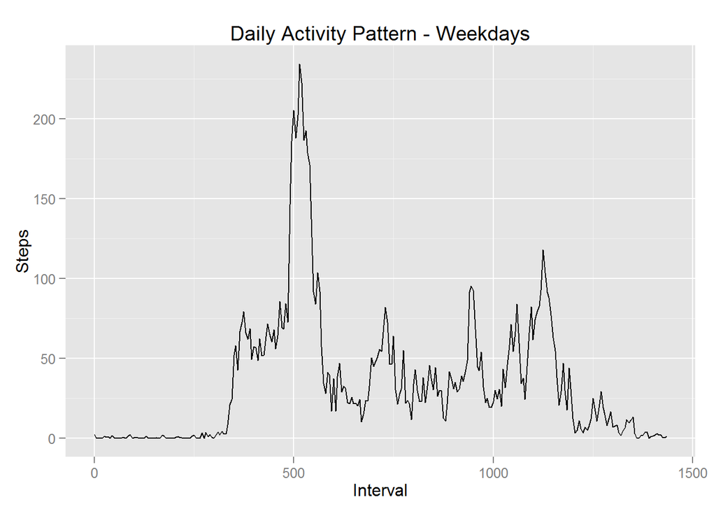

```r
intervals <- factor(df$interval)
wds <- factor(df$wd)
byIntervals <- tapply(df$steps, list(intervals, wds), mean, na.rm=TRUE)
qplot(x=as.integer(names(byIntervals[,2])), y=byIntervals[,2], geom="line",
      stat="identity", xlab="Interval",
      ylab="Steps", main="Daily Activity Pattern - Weekdays")
```

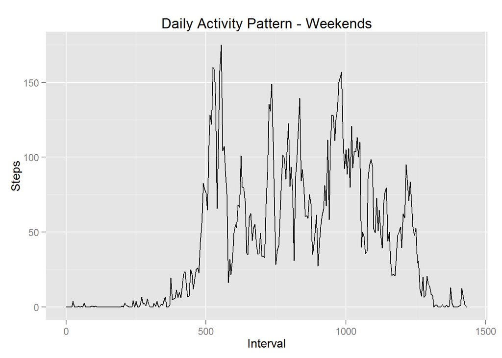

```r
qplot(x=as.integer(names(byIntervals[,1])), y=byIntervals[,1], geom="line",
      stat="identity", xlab="Interval",
      ylab="Steps", main="Daily Activity Pattern - Weekends")
```